# QM3-GroupWork

J.Larrodé

03/11/2026

# *Research Question*

## Step 1 : Loading Data

Before all we need to install the packages needed to conduct our analysis *should that go in the Intro maybe?*

```r
install.packages("readxl")
install.packages("stargazer")
install.packages("ggplot2")
install.packages("performance")
```

*“readxl” extracts the data from excel spreadsheets.*  
*“stargazer” and “ggplot2” are used to create plots.*  
*“performance” package allows to use the **model_comparison** R function.*

We also call their libraries to load the packages.

```r
library(readxl)
library(stargazer)
library(ggplot2)
library(performance)
```

Next we import the datasets we have chosen to use for our analysis.  
We chose these because pur analysis deals with the environment and the relationship between pollution and various economic factors.

The following allow us to measure pollution/CO2 impact :

```r
Renewable_energies_dataset <- read_excel("Renewable_energies_dataset.xls")
C02_emissions_per_capita <- read_excel("C02 emissions per capita.xls")
```

While these ones are the different economic factors :

```r
GDP_per_capita_dataset <- read_excel("GDP per capita dataset.xls")
Gross_Capital_Formation_percentage_of_GDP_ <- read_excel("Gross Capital Formation (percentage of GDP).xls")
Urban_population_percentage_of_total_ <- read_excel("Urban population (percentage of total).xls")
Total_natural_resources_rents_of_GDP_ <- read_excel("Total natural resources rents (% of GDP).xls")
Trade_of_GDP_ <- read_excel("Trade (% of GDP).xls")
Foreign_direct_investement<- read_excel("Foreign direct investment, net inflows (% of GDP).xls")
```

Each dataset has data for multiple years. For accuracy we chose to focus on the most recent year *(why only 1 year?)* with the most amount of data, this proved to be the year of 2021 :

*not sure what this does*

```r
recentdata<-data.frame(Country = Renewable_energies_dataset$`Country Name`,
                       Renewable_energy_consumption = Renewable_energies_dataset$`2021`)
```

```r
recentdata <- within(recentdata, {
              GDP_per_capita = GDP_per_capita_dataset$`2021`
              Gross_Capital  = Gross_Capital_Formation_percentage_of_GDP_$`2021`
              Urban_pop      = Urban_population_percentage_of_total_$`2021`
              Total_natural  = Total_natural_resources_rents_of_GDP_$`2021`
              Trade_GDP      = Trade_of_GDP_$`2021`
              Foreign_direct_investement= Foreign_direct_investement$`2021`
              C02_emissions  = C02_emissions_per_capita$`2021`
              })
recentdata <-na.omit(recentdata)
```

**Table 1**  
*( descriptive statistics )*

```r
stargazer(recentdata, type="text", digits=1,
          title ="Table 1: Summary Statistics of the Variables (2021)")
```

```
##
## Table 1: Summary Statistics of the Variables (2021)
## ==================================================================
## Statistic                     N    Mean   St. Dev.  Min     Max
## ------------------------------------------------------------------
## Renewable_energy_consumption 162   32.4     27.1    0.0    96.3
## C02_emissions                162   4.8      7.9    0.002   74.7
## Foreign_direct_investement   162   6.8      34.3   -14.4   433.6
## Trade_GDP                    162   90.0     60.2    4.1    402.5
## Total_natural                162   7.1      10.6    0.0    61.0
## Urban_pop                    162   61.7     21.8   16.5    100.0
## Gross_Capital                162   23.8     8.1    -15.7   44.4
## GDP_per_capita               162 15,700.2 21,662.0 396.0 110,873.1
## ------------------------------------------------------------------
```

## Step 2 : Bivariate and Logarithmic OLS

We choose to use the Ordinary Least Squares (OLS) regression because it is considered the Best Linear Unbiased Estimator (BLUE). It has a low variance level, it uses the true values of the estimated alpha and beta and on a large sample it will have a precise estimation.

First, we look at the relationship between Renewable Energy Consumption and GPD per capita.

```r
modA1 <- lm(Renewable_energy_consumption ~ GDP_per_capita, data = recentdata)
stargazer(modA1, type = "text",
          title ="Table 2: OLS results for Renewable Energy Consumption and GDP per capita")
```

```
##
## Table 2: OLS results for Renewable Energy Consumption and GDP per capita
## ================================================
##                         Dependent variable:
##                     ----------------------------
##                     Renewable_energy_consumption
## ------------------------------------------------
## GDP_per_capita               -0.0004***
##                               (0.0001)
##
## Constant                     38.460***
##                               (2.514)
##
## ------------------------------------------------
## Observations                    162
## R2                             0.095
## Adjusted R2                    0.089
## Residual Std. Error      25.886 (df = 160)
## F Statistic           16.744*** (df = 1; 160)
## ================================================
## Note:                *p<0.1; **p<0.05; ***p<0.01
```

These results indicate a *negative and statistically significant* result.

The R-squared value is of 0.095 which indicates that GDP per capita explains approximately 9.5% of the variation in renewable energy consumption across the 162 countries included in our sample.

The coefficient is -0.0004 ; which assumes a negative correlation ; we can infer that countries with higher GDP per capita tend to have lower shares of renewable energy consumption, on average.

Though significant, the p-value is below the conventional 0.05, this result indicates that there are other variables that probably play a bigger role on the consumption of renewable energy.

It is also important to plot the relationship to assess the fit of the model used.

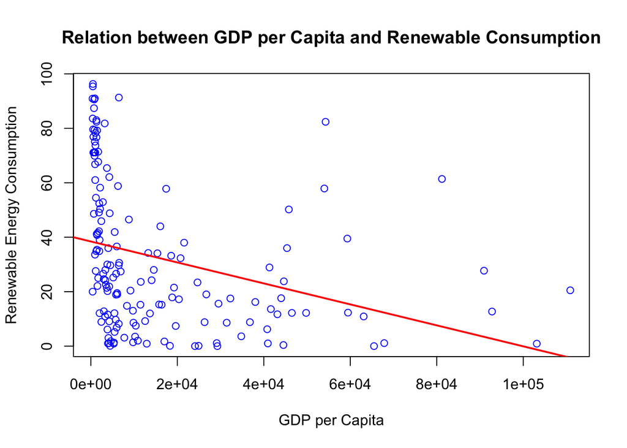

```r
plot(recentdata$GDP_per_capita, recentdata$Renewable_energy_consumption,
     xlab = "GDP per Capita",
     ylab = "Renewable Energy Consumption",
     main = "Relation between GDP per Capita and Renewable Consumption",
     col="blue")
abline(modA1, col="red", lwd=2)
```

Thought increase the precision and readability of the model we add the log function to the GDP.

```r
modA2 <- lm(Renewable_energy_consumption ~ log(GDP_per_capita), data =recentdata)
stargazer(modA2, type = "text",
          title ="Table 3: OLS results for log(Renewable Energy Consumption) and log(GDP per capita)")
```

[output not shown]

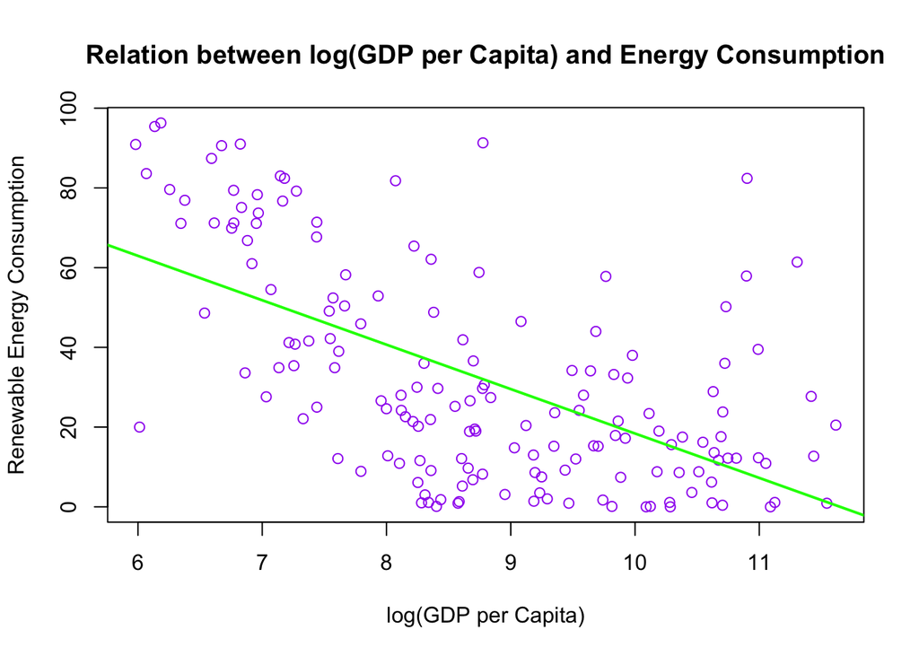

```r
plot(log(recentdata$GDP_per_capita), recentdata$Renewable_energy_consumption,
     xlab = "log(GDP per Capita)",
     ylab = "Renewable Energy Consumption",
     main = "Relation between log(GDP per Capita) and Energy Consumption",
     col="purple")
abline(modA2, col="green", lwd=2)
```

*not sure about the distribution of residuals here*

*We do a similar analysis of the next few*

```r
modA3 <- lm(Renewable_energy_consumption ~ Gross_Capital, data = recentdata)
stargazer(modA3, type = "text",
          title ="Table 4: OLS results for Renewable Energy Consumption and Gross Capital Formation")
```

```
##
## Table 4: OLS results for Renewable Energy Consumption and Gross Capital Formation
## ================================================
##                         Dependent variable:
##                     ----------------------------
##                     Renewable_energy_consumption
## ------------------------------------------------
## Gross_Capital                  -0.056
##                               (0.265)
##
## Constant                     33.745***
##                               (6.672)
##
## ------------------------------------------------
## Observations                    162
## R2                             0.0003
## Adjusted R2                    -0.006
## Residual Std. Error      27.203 (df = 160)
## F Statistic             0.045 (df = 1; 160)
## ================================================
## Note:                *p<0.1; **p<0.05; ***p<0.01
```

No significant relationship between Renewable Energy Consumption and Gross Capital Formation *explain why*

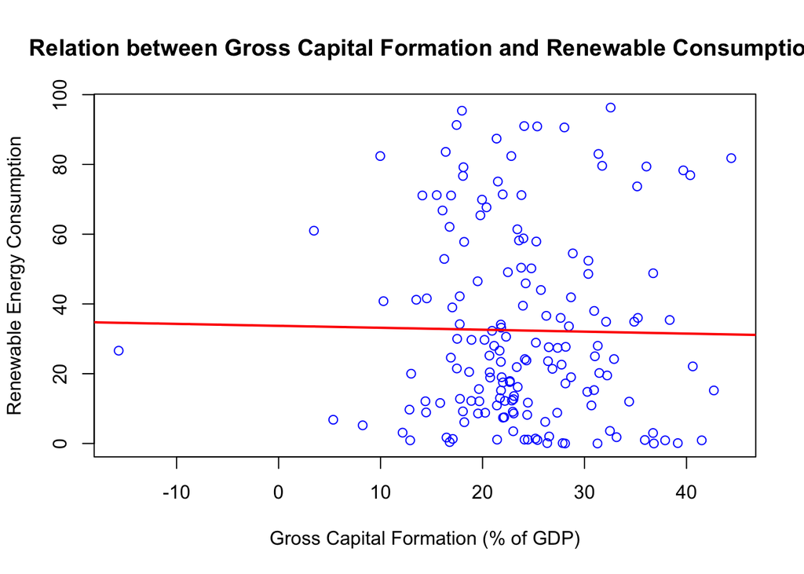

```r
plot(recentdata$Gross_Capital, recentdata$Renewable_energy_consumption,
     xlab = "Gross Capital Formation (% of GDP)",
     ylab = "Renewable Energy Consumption",
     main = "Relation between Gross Capital Formation and Renewable Consumption",
     col="blue")
abline(modA3, col="red", lwd=2)
```

**Urban population**

```r
modA4 <- lm(Renewable_energy_consumption ~ Urban_pop, data = recentdata)
stargazer(modA4, type = "text",
          title ="Table 5: OLS results for Renewable Energy Consumption and Urban Population")
```

```
##
## Table 5: OLS results for Renewable Energy Consumption and Urban Population
## ================================================
##                         Dependent variable:
##                     ----------------------------
##                     Renewable_energy_consumption
## ------------------------------------------------
## Urban_pop                    -0.606***
##                               (0.086)
##
## Constant                     69.851***
##                               (5.623)
##
## ------------------------------------------------
## Observations                    162
## R2                             0.237
## Adjusted R2                    0.233
## Residual Std. Error      23.758 (df = 160)
## F Statistic           49.825*** (df = 1; 160)
## ================================================
## Note:                *p<0.1; **p<0.05; ***p<0.01
```

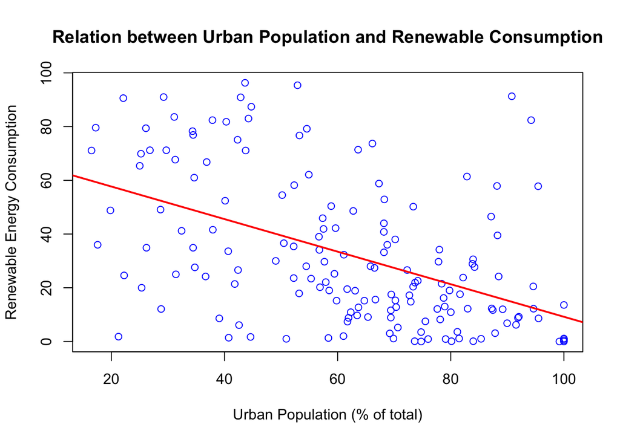

```r
plot(recentdata$Urban_pop, recentdata$Renewable_energy_consumption,
     xlab = "Urban Population (% of total)",
     ylab = "Renewable Energy Consumption",
     main = "Relation between Urban Population and Renewable Consumption",
     col="blue")
abline(modA4, col="red", lwd=2)
```

Again, adding the log function to increase precision

```r
modA5<-lm(Renewable_energy_consumption ~ log(Urban_pop), data =recentdata)
stargazer(modA5, type = "text",
          title ="Table 6: OLS results for Renewable Energy Consumption and log(Urban Population)")
```

```
##
## Table 6: OLS results for Renewable Energy Consumption and log(Urban Population)
## ================================================
##                         Dependent variable:
##                     ----------------------------
##                     Renewable_energy_consumption
## ------------------------------------------------
## log(Urban_pop)               -30.838***
##                               (4.446)
##
## Constant                     157.159***
##                               (18.081)
##
## ------------------------------------------------
## Observations                    162
## R2                             0.231
## Adjusted R2                    0.226
## Residual Std. Error      23.855 (df = 160)
## F Statistic           48.119*** (df = 1; 160)
## ================================================
## Note:                *p<0.1; **p<0.05; ***p<0.01
```

the log function doesnt improve the analysis.

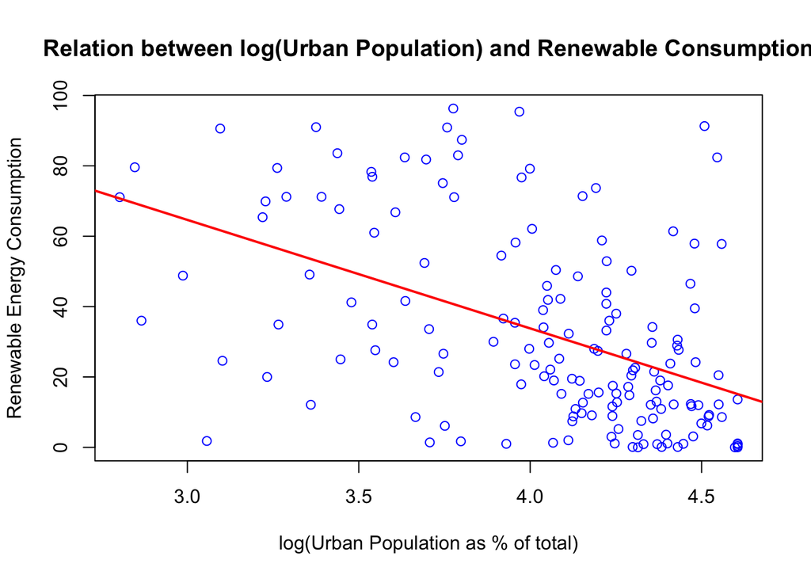

```r
plot(log(recentdata$Urban_pop), recentdata$Renewable_energy_consumption,
     xlab = "log(Urban Population as % of total)",
     ylab = "Renewable Energy Consumption",
     main = "Relation between log(Urban Population) and Renewable Consumption",
     col="blue")
abline(modA5, col="red", lwd=2)
```

*more variables*

```r
modA6 <- lm(Renewable_energy_consumption ~ Total_natural, data = recentdata)
stargazer(modA6, type = "text",
          title ="Table 7: OLS results for Renewable Energy Consumption and Total Natural Resources")
```

```
##
## Table 7: OLS results for Renewable Energy Consumption and Total Natural Resources
## ================================================
##                         Dependent variable:
##                     ----------------------------
##                     Renewable_energy_consumption
## ------------------------------------------------
## Total_natural                  0.036
##                               (0.203)
##
## Constant                     32.153***
##                               (2.575)
##
## ------------------------------------------------
## Observations                    162
## R2                             0.0002
## Adjusted R2                    -0.006
## Residual Std. Error      27.204 (df = 160)
## F Statistic             0.032 (df = 1; 160)
## ================================================
## Note:                *p<0.1; **p<0.05; ***p<0.01
```

There is no significant relationship between those two variables

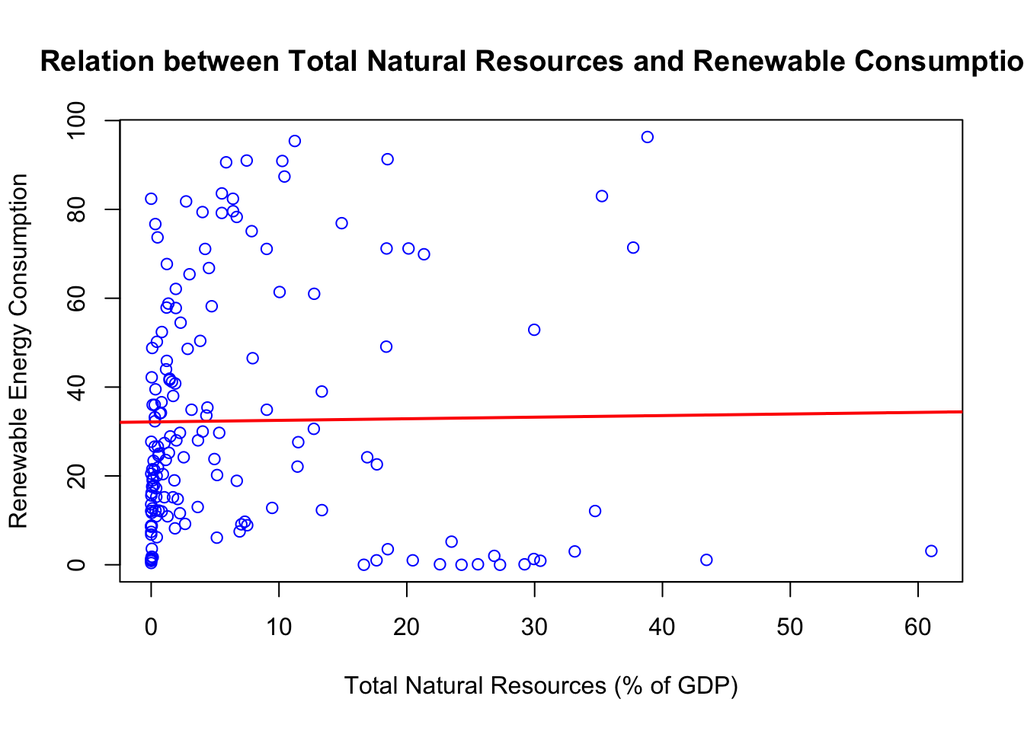

```r
plot(recentdata$Total_natural, recentdata$Renewable_energy_consumption,
     xlab = "Total Natural Resources (% of GDP)",
     ylab = "Renewable Energy Consumption",
     main = "Relation between Total Natural Resources and Renewable Consumption",
     col="blue")
abline(modA6, col="red", lwd=2)
```

*last variable*

```r
modA7 <- lm(Renewable_energy_consumption ~ Trade_GDP, data = recentdata)
stargazer(modA7, type = "text",
          title ="Table 8: OLS results for Renewable Energy Consumption and Trade as % of GDP")
```

```
##
## Table 8: OLS results for Renewable Energy Consumption and Trade as % of GDP
## ================================================
##                         Dependent variable:
##                     ----------------------------
##                     Renewable_energy_consumption
## ------------------------------------------------
## Trade_GDP                    -0.144***
##                               (0.034)
##
## Constant                     45.321***
##                               (3.652)
##
## ------------------------------------------------
## Observations                    162
## R2                             0.101
## Adjusted R2                    0.096
## Residual Std. Error      25.791 (df = 160)
## F Statistic           18.055*** (df = 1; 160)
## ================================================
## Note:                *p<0.1; **p<0.05; ***p<0.01
```

Good relationship between the variables

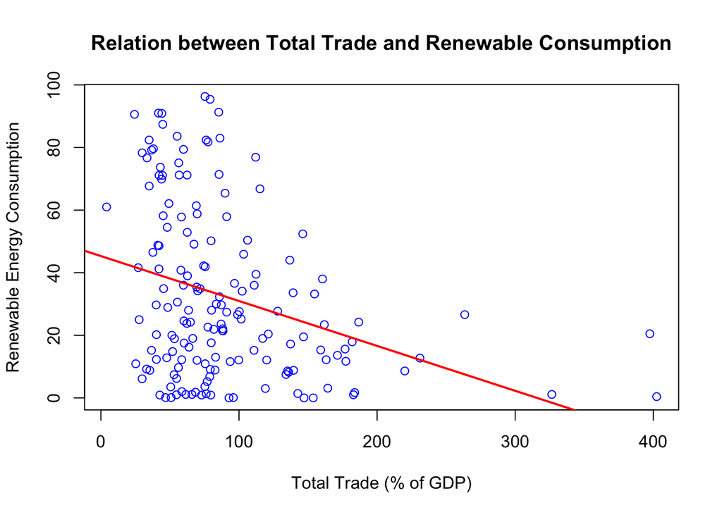

```r
plot(recentdata$Trade_GDP, recentdata$Renewable_energy_consumption,
     xlab = "Total Trade (% of GDP)",
     ylab = "Renewable Energy Consumption",
     main = "Relation between Total Trade and Renewable Consumption",
     col="blue")
abline(modA7, col="red", lwd=2)
```

We try using logarithms in this case

```r
modA8 <-lm(Renewable_energy_consumption ~ log(Trade_GDP), data =recentdata)
stargazer(modA8, type = "text",
          title ="Table 9: OLS results for Renewable Energy Consumption and log(Trade as % of GDP)")
```

```
##
## Table 9: OLS results for Renewable Energy Consumption and log(Trade as % of GDP)
## ================================================
##                         Dependent variable:
##                     ----------------------------
##                     Renewable_energy_consumption
## ------------------------------------------------
## log(Trade_GDP)               -15.728***
##                               (3.397)
##
## Constant                     100.456***
##                               (14.834)
##
## ------------------------------------------------
## Observations                    162
## R2                             0.118
## Adjusted R2                    0.113
## Residual Std. Error      25.549 (df = 160)
## F Statistic           21.434*** (df = 1; 160)
## ================================================
## Note:                *p<0.1; **p<0.05; ***p<0.01
```

It slightly improves using logarithms

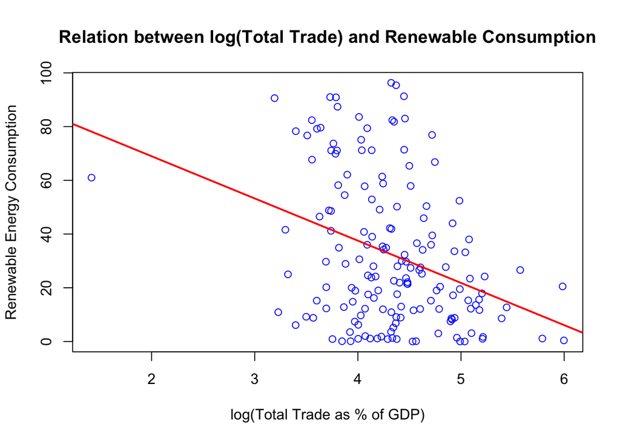

```r
plot(log(recentdata$Trade_GDP), recentdata$Renewable_energy_consumption,
     xlab = "log(Total Trade as % of GDP)",
     ylab = "Renewable Energy Consumption",
     main = "Relation between log(Total Trade) and Renewable Consumption",
     col="blue")
abline(modA8, col="red", lwd=2)
```

We check the Direct Foreign Investment

```r
modA9 <- lm(Renewable_energy_consumption ~ Foreign_direct_investement, data = recentdata)
summary(modA9)
```

```
##
## Call:
## lm(formula = Renewable_energy_consumption ~ Foreign_direct_investement,
##     data = recentdata)
##
## Residuals:
##     Min      1Q  Median      3Q     Max
## -32.918 -21.392  -7.926  17.554  63.620
##
## Coefficients:
##                            Estimate Std. Error t value Pr(>|t|)
## (Intercept)                32.87557    2.17063  15.146   <2e-16 ***
## Foreign_direct_investement -0.06894    0.06223  -1.108     0.27
## ---
## Signif. codes:  0 '***' 0.001 '**' 0.01 '*' 0.05 '.' 0.1 ' ' 1
##
## Residual standard error: 27.1 on 160 degrees of freedom
## Multiple R-squared:  0.007612,   Adjusted R-squared:  0.001409
## F-statistic: 1.227 on 1 and 160 DF,  p-value: 0.2696
```

```r
stargazer(modA9, type = "text",
          title ="Table 10: OLS results for Renewable Energy Consumption and Foreign direct investment")
```

```
##
## Table 10: OLS results for Renewable Energy Consumption and Foreign direct investment
## =======================================================
##                                Dependent variable:
##                            ----------------------------
##                            Renewable_energy_consumption
## -------------------------------------------------------
## Foreign_direct_investement            -0.069
##                                      (0.062)
##
## Constant                            32.876***
##                                      (2.171)
##
## -------------------------------------------------------
## Observations                           162
## R2                                    0.008
## Adjusted R2                           0.001
## Residual Std. Error             27.103 (df = 160)
## F Statistic                    1.227 (df = 1; 160)
## =======================================================
## Note:                       *p<0.1; **p<0.05; ***p<0.01
```

There is no significant relationship between those two variables

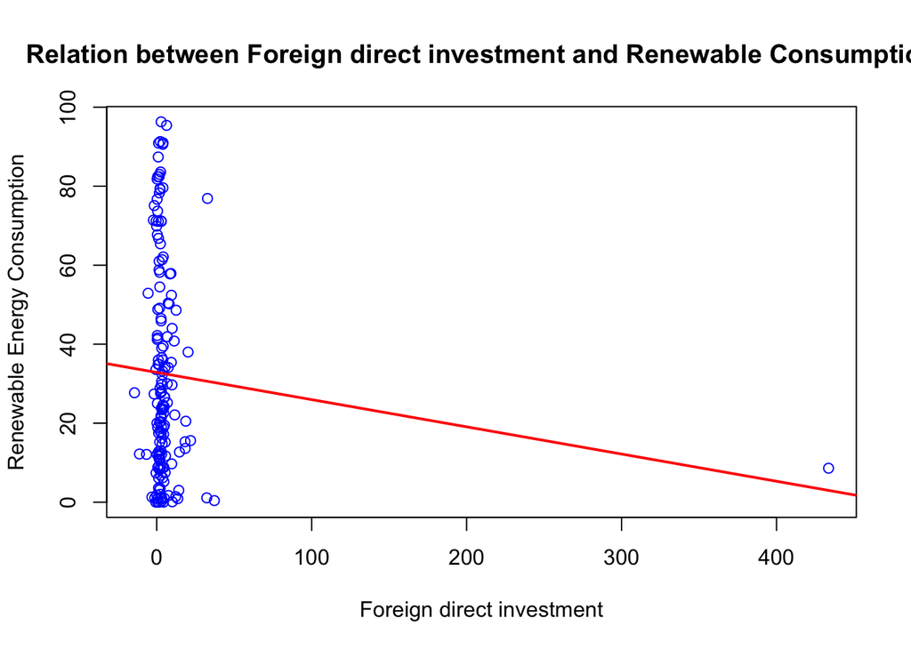

```r
plot(recentdata$Foreign_direct_investement, recentdata$Renewable_energy_consumption,
     xlab = "Foreign direct investment",
     ylab = "Renewable Energy Consumption",
     main = "Relation between Foreign direct investment and Renewable Consumption",
     col="blue")
abline(modA9, col="red", lwd=2)
```

## Step 3 : Multivariable models and model selection

Finally, we are going to do a multivariate OLS *explain why*

```r
mod_multiple <-lm(Renewable_energy_consumption ~
               log(GDP_per_capita) +
               Urban_pop +
               Gross_Capital +
               log(Trade_GDP) +
               Total_natural +
               Foreign_direct_investement ,
               data = recentdata)
stargazer(mod_multiple, type = "text",
          title ="Table 11: Multivariable OLS results for Renewable Energy Consumption and the other variables")
```

```
##
## Table 11: Multivariable OLS results for Renewable Energy Consumption and the other variables
## =======================================================
##                                Dependent variable:
##                            ----------------------------
##                            Renewable_energy_consumption
## -------------------------------------------------------
## log(GDP_per_capita)                 -10.039***
##                                      (2.023)
##
## Urban_pop                             -0.060
##                                      (0.127)
##
## Gross_Capital                         -0.018
##                                      (0.216)
##
## log(Trade_GDP)                        -5.167
##                                      (3.250)
##
## Total_natural                        -0.287*
##                                      (0.173)
##
## Foreign_direct_investement           -0.0004
##                                      (0.052)
##
## Constant                            148.687***
##                                      (15.956)
##
## -------------------------------------------------------
## Observations                           162
## R2                                    0.378
## Adjusted R2                           0.354
## Residual Std. Error             21.796 (df = 155)
## F Statistic                  15.718*** (df = 6; 155)
## =======================================================
## Note:                       *p<0.1; **p<0.05; ***p<0.01
```

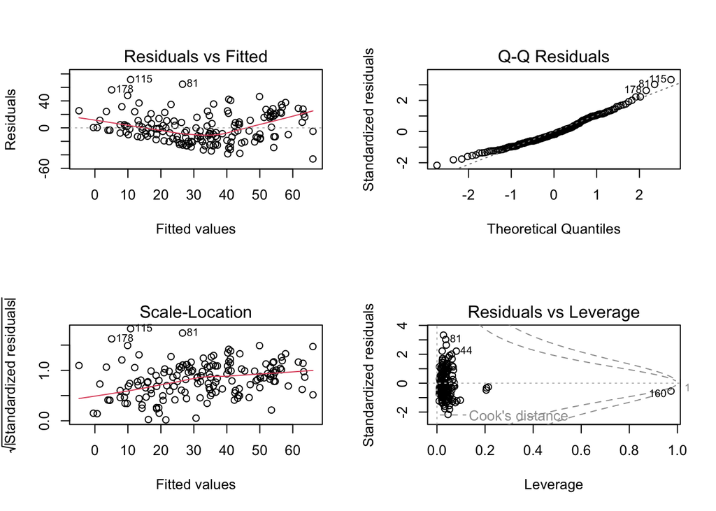

```r
par(mfrow = c(2, 2))
plot(mod_multiple)
```

Really good performing model, and log(GDP_per_capita) remains highly significant,but Trade_GDP and Urban_pop lose significance. We are going to compare the models we have *with the R function*

```r
model_comparison <- compare_performance(modA1, modA2, modA3, modA4, modA5, modA6,
                                        modA7, modA8, modA9, mod_multiple, rank = TRUE)
print_md(model_comparison)
```

Comparison of Model Performance Indices

| Name | Model | R2 | R2 (adj.) | RMSE | Sigma | AIC weights | AICc weights | BIC weights | Performance-Score |
| --- | --- | --- | --- | --- | --- | --- | --- | --- | --- |
| modA2 | lm | 0.35 | 0.35 | 21.76 | 21.89 | 0.848 | 0.892 | 1.000 | 97.46% |
| mod_multiple | lm | 0.38 | 0.35 | 21.32 | 21.80 | 0.152 | 0.108 | 7.94e-05 | 61.42% |
| modA4 | lm | 0.24 | 0.23 | 23.61 | 23.76 | 1.48e-06 | 1.56e-06 | 1.74e-06 | 36.09% |
| modA5 | lm | 0.23 | 0.23 | 23.71 | 23.86 | 7.64e-07 | 8.04e-07 | 9.00e-07 | 35.11% |
| modA8 | lm | 0.12 | 0.11 | 25.39 | 25.55 | 1.14e-11 | 1.20e-11 | 1.34e-11 | 17.64% |
| modA7 | lm | 0.10 | 0.10 | 25.63 | 25.79 | 2.48e-12 | 2.61e-12 | 2.92e-12 | 15.11% |
| modA1 | lm | 0.09 | 0.09 | 25.73 | 25.89 | 1.36e-12 | 1.43e-12 | 1.61e-12 | 14.10% |
| modA9 | lm | 7.61e-03 | 1.41e-03 | 26.94 | 27.10 | 7.98e-16 | 8.40e-16 | 9.41e-16 | 1.09% |
| modA3 | lm | 2.79e-04 | -5.97e-03 | 27.03 | 27.20 | 4.40e-16 | 4.63e-16 | 5.18e-16 | 0.01% |
| modA6 | lm | 1.99e-04 | -6.05e-03 | 27.04 | 27.20 | 4.37e-16 | 4.60e-16 | 5.15e-16 | 0.00% |

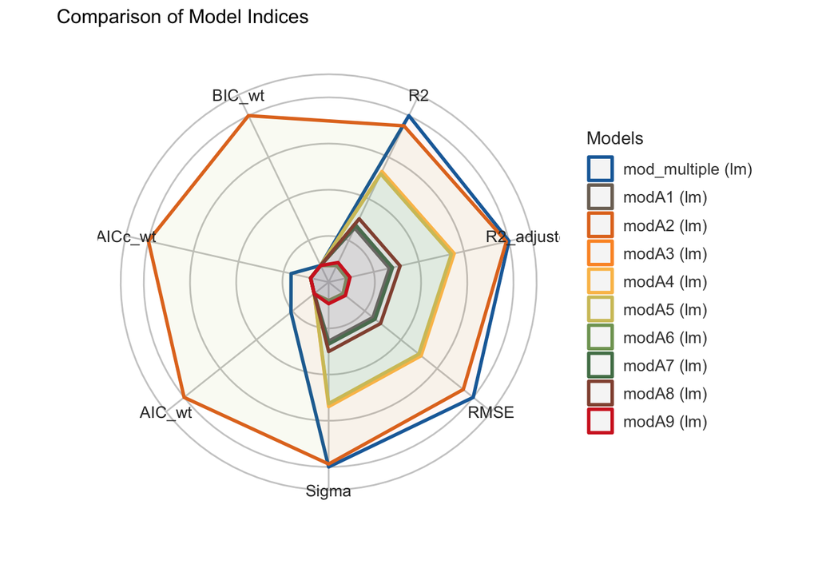

```r
par(mfrow = c(1, 1))
plot(model_comparison)
```

The best model is modA2 *explain*

## Step 4 : Environmental Impact Analysis

As a conclusion we are going to check if there is a relation between Renewable Energy Consumption and CO2 emissions per capita *why*

```r
modA10 <- lm(Renewable_energy_consumption ~ C02_emissions, data = recentdata)
stargazer(modA10, type = "text",
          title ="Table 12: OLS results for Renewable Energy Consumption and C02 emissions per capita")
```

```
##
## Table 12: OLS results for Renewable Energy Consumption and C02 emissions per capita
## ================================================
##                         Dependent variable:
##                     ----------------------------
##                     Renewable_energy_consumption
## ------------------------------------------------
## C02_emissions                -1.383***
##                               (0.247)
##
## Constant                     39.096***
##                               (2.289)
##
## ------------------------------------------------
## Observations                    162
## R2                             0.164
## Adjusted R2                    0.159
## Residual Std. Error      24.873 (df = 160)
## F Statistic           31.442*** (df = 1; 160)
## ================================================
## Note:                *p<0.1; **p<0.05; ***p<0.01
```

Strong relation *why*

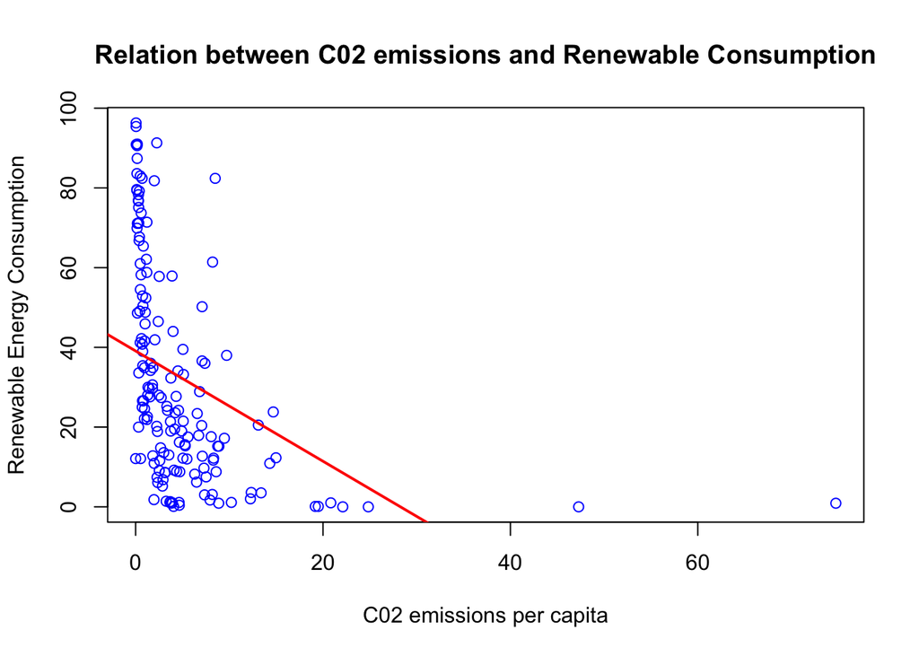

```r
plot(recentdata$C02_emissions, recentdata$Renewable_energy_consumption,
     xlab = "C02 emissions per capita",
     ylab = "Renewable Energy Consumption",
     main = "Relation between C02 emissions and Renewable Consumption",
     col="blue")
abline(modA10, col="red", lwd=2)
```

We try with a logarithmic model

```r
modA11 <- lm(Renewable_energy_consumption ~ log(C02_emissions), data = recentdata)
stargazer(modA11, type = "text",
          title ="Table 13: OLS results for Renewable Energy Consumption and log(C02 emissions per capita)")
```

```
##
## Table 13: OLS results for Renewable Energy Consumption and log(C02 emissions per capita)
## ================================================
##                         Dependent variable:
##                     ----------------------------
##                     Renewable_energy_consumption
## ------------------------------------------------
## log(C02_emissions)           -12.378***
##                               (1.035)
##
## Constant                     41.375***
##                               (1.725)
##
## ------------------------------------------------
## Observations                    162
## R2                             0.472
## Adjusted R2                    0.469
## Residual Std. Error      19.773 (df = 160)
## F Statistic           142.927*** (df = 1; 160)
## ================================================
## Note:                *p<0.1; **p<0.05; ***p<0.01
```

Much better using logarithms!

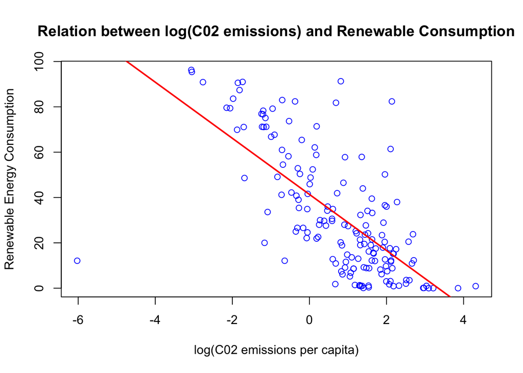

```r
plot(log(recentdata$C02_emissions), recentdata$Renewable_energy_consumption,
     xlab = "log(C02 emissions per capita)",
     ylab = "Renewable Energy Consumption",
     main = "Relation between log(C02 emissions) and Renewable Consumption",
     col="blue")
abline(modA11, col="red", lwd=2)
```